# Project: FBI Gun data

- Introduction
- Data Wrangling
- Exploratory Data Analysis
- Conclusions

## Introduction

**Gun safety is of valuable concern to the United States security. For the reason of personal security/hunting purposes, it is possible for individual to own guns. To keep a track of the number of buyers, and also to be informed of the backkground of the prospective client is of utmost importance for gun dealers.**

**Hence to keep track of this, FBI's National Instant Criminal Background Check System (NICS) has maintained a database of the background of buyers. The NICS is hence used by dealers to determine whether a prospective buyer is eligible to buy firearms or explosives. Gun shops call into this system to ensure that each customer does not have a criminal record or isn’t otherwise ineligible to make a purchase. Further, there is also a record on the number of buyers across states within the country.**

**In this project, we will use the dataset (firearms checks made by NICS) to determine and analyse trends in the firearms buyers in the US with respect to the states,in particular address the following questions:**  
**1. The states with highest gun purchasers.**  
**2. The state with highest total gun purchaser/rental and its composition.**  
**3. The overall trend of the United States gun purchases for the amount of data available.**

```python
"""Import the relevant libraries required for the project"""

import numpy as np
import pandas as pd
import matplotlib.pyplot as plt
import seaborn as sns
from matplotlib import cm
import matplotlib as mpl
%matplotlib inline
```

## Data Wrangling

### General Properties

```python
"""Read the CSV file containing the NCIS dataset"""
df1 = pd.read_csv('gun_data.csv')
df1.head()
```

|  | month | state | permit | permit_recheck | handgun | long_gun | other | multiple | admin | prepawn_handgun | ... | returned_other | rentals_handgun | rentals_long_gun | private_sale_handgun | private_sale_long_gun | private_sale_other | return_to_seller_handgun | return_to_seller_long_gun | return_to_seller_other | totals |
| --- | --- | --- | --- | --- | --- | --- | --- | --- | --- | --- | --- | --- | --- | --- | --- | --- | --- | --- | --- | --- | --- |
| 0 | 2017-09 | Alabama | 16717.0 | 0.0 | 5734.0 | 6320.0 | 221.0 | 317 | 0.0 | 15.0 | ... | 0.0 | 0.0 | 0.0 | 9.0 | 16.0 | 3.0 | 0.0 | 0.0 | 3.0 | 32019 |
| 1 | 2017-09 | Alaska | 209.0 | 2.0 | 2320.0 | 2930.0 | 219.0 | 160 | 0.0 | 5.0 | ... | 0.0 | 0.0 | 0.0 | 17.0 | 24.0 | 1.0 | 0.0 | 0.0 | 0.0 | 6303 |
| 2 | 2017-09 | Arizona | 5069.0 | 382.0 | 11063.0 | 7946.0 | 920.0 | 631 | 0.0 | 13.0 | ... | 0.0 | 0.0 | 0.0 | 38.0 | 12.0 | 2.0 | 0.0 | 0.0 | 0.0 | 28394 |
| 3 | 2017-09 | Arkansas | 2935.0 | 632.0 | 4347.0 | 6063.0 | 165.0 | 366 | 51.0 | 12.0 | ... | 0.0 | 0.0 | 0.0 | 13.0 | 23.0 | 0.0 | 0.0 | 2.0 | 1.0 | 17747 |
| 4 | 2017-09 | California | 57839.0 | 0.0 | 37165.0 | 24581.0 | 2984.0 | 0 | 0.0 | 0.0 | ... | 0.0 | 0.0 | 0.0 | 0.0 | 0.0 | 0.0 | 0.0 | 0.0 | 0.0 | 123506 |

5 rows × 27 columns

## Data Cleaning

**Now, we will clean up the data set and look for missing/null values**

```python
"""Gives the number of rows/columns"""
df1.shape
```

```
(12485, 27)
```

```python
"""Gives the type of values present in the dataset"""
df1.info();
```

```
<class 'pandas.core.frame.DataFrame'>
RangeIndex: 12485 entries, 0 to 12484
Data columns (total 27 columns):
month                        12485 non-null object
state                        12485 non-null object
permit                       12461 non-null float64
permit_recheck               1100 non-null float64
handgun                      12465 non-null float64
long_gun                     12466 non-null float64
other                        5500 non-null float64
multiple                     12485 non-null int64
admin                        12462 non-null float64
prepawn_handgun              10542 non-null float64
prepawn_long_gun             10540 non-null float64
prepawn_other                5115 non-null float64
redemption_handgun           10545 non-null float64
redemption_long_gun          10544 non-null float64
redemption_other             5115 non-null float64
returned_handgun             2200 non-null float64
returned_long_gun            2145 non-null float64
returned_other               1815 non-null float64
rentals_handgun              990 non-null float64
rentals_long_gun             825 non-null float64
private_sale_handgun         2750 non-null float64
private_sale_long_gun        2750 non-null float64
private_sale_other           2750 non-null float64
return_to_seller_handgun     2475 non-null float64
return_to_seller_long_gun    2750 non-null float64
return_to_seller_other       2255 non-null float64
totals                       12485 non-null int64
dtypes: float64(23), int64(2), object(2)
memory usage: 2.6+ MB
```

```python
"""Gives a description of the values in the dataset"""
df1.describe()
```

|  | permit | permit_recheck | handgun | long_gun | other | multiple | admin | prepawn_handgun | prepawn_long_gun | prepawn_other | ... | returned_other | rentals_handgun | rentals_long_gun | private_sale_handgun | private_sale_long_gun | private_sale_other | return_to_seller_handgun | return_to_seller_long_gun | return_to_seller_other | totals |
| --- | --- | --- | --- | --- | --- | --- | --- | --- | --- | --- | --- | --- | --- | --- | --- | --- | --- | --- | --- | --- | --- |
| count | 12461.000000 | 1100.000000 | 12465.000000 | 12466.000000 | 5500.000000 | 12485.000000 | 12462.000000 | 10542.000000 | 10540.000000 | 5115.000000 | ... | 1815.000000 | 990.000000 | 825.000000 | 2750.000000 | 2750.000000 | 2750.000000 | 2475.000000 | 2750.000000 | 2255.000000 | 12485.000000 |
| mean | 6413.629404 | 1165.956364 | 5940.881107 | 7810.847585 | 360.471636 | 268.603364 | 58.898090 | 4.828021 | 7.834156 | 0.165591 | ... | 1.027548 | 0.076768 | 0.087273 | 14.936000 | 11.602909 | 1.030182 | 0.402020 | 0.441818 | 0.105987 | 21595.725911 |
| std | 23752.338269 | 9224.200609 | 8618.584060 | 9309.846140 | 1349.478273 | 783.185073 | 604.814818 | 10.907756 | 16.468028 | 1.057105 | ... | 4.386296 | 0.634503 | 0.671649 | 71.216021 | 54.253090 | 4.467843 | 1.446568 | 1.528223 | 0.427363 | 32591.418387 |
| min | 0.000000 | 0.000000 | 0.000000 | 0.000000 | 0.000000 | 0.000000 | 0.000000 | 0.000000 | 0.000000 | 0.000000 | ... | 0.000000 | 0.000000 | 0.000000 | 0.000000 | 0.000000 | 0.000000 | 0.000000 | 0.000000 | 0.000000 | 0.000000 |
| 25% | 0.000000 | 0.000000 | 865.000000 | 2078.250000 | 17.000000 | 15.000000 | 0.000000 | 0.000000 | 0.000000 | 0.000000 | ... | 0.000000 | 0.000000 | 0.000000 | 0.000000 | 0.000000 | 0.000000 | 0.000000 | 0.000000 | 0.000000 | 4638.000000 |
| 50% | 518.000000 | 0.000000 | 3059.000000 | 5122.000000 | 121.000000 | 125.000000 | 0.000000 | 0.000000 | 1.000000 | 0.000000 | ... | 0.000000 | 0.000000 | 0.000000 | 0.000000 | 0.000000 | 0.000000 | 0.000000 | 0.000000 | 0.000000 | 12399.000000 |
| 75% | 4272.000000 | 0.000000 | 7280.000000 | 10380.750000 | 354.000000 | 301.000000 | 0.000000 | 5.000000 | 8.000000 | 0.000000 | ... | 0.000000 | 0.000000 | 0.000000 | 2.000000 | 4.000000 | 0.000000 | 0.000000 | 0.000000 | 0.000000 | 25453.000000 |
| max | 522188.000000 | 116681.000000 | 107224.000000 | 108058.000000 | 77929.000000 | 38907.000000 | 28083.000000 | 164.000000 | 269.000000 | 49.000000 | ... | 64.000000 | 12.000000 | 12.000000 | 1017.000000 | 777.000000 | 71.000000 | 28.000000 | 17.000000 | 4.000000 | 541978.000000 |

8 rows × 25 columns

**We notice that there are many columns in the dataset that we will not require and/or not useful for the present study. Hence, we will remove those columns by dropping them off as shown below.**

```python
"""Dropping irrelevant columns in the dataset"""
df1.drop(['permit_recheck', 'other', 'multiple','admin','prepawn_other','redemption_other', 'rentals_handgun','rentals_long_gun','returned_other','private_sale_other','return_to_seller_other'],axis=1, inplace = True)
```

**Since there are null values for all the gun columns below below the year 2015 except for handgun and long gun, we will only consider the values after 2015 where necessary.**

```python
"""Creating a new dataframe for the trimmed dataset"""

after_2015 = df1[df1["month"] >= "2015-01" ]
```

**We will then obtain a dataframe with the right dimension and no null values as shown in the information below.**

```python
"""Understanding the information about the trimmed dataset"""
after_2015.info()
```

```
<class 'pandas.core.frame.DataFrame'>
Int64Index: 1815 entries, 0 to 1814
Data columns (total 16 columns):
month                        1815 non-null object
state                        1815 non-null object
permit                       1815 non-null float64
handgun                      1815 non-null float64
long_gun                     1815 non-null float64
prepawn_handgun              1815 non-null float64
prepawn_long_gun             1815 non-null float64
redemption_handgun           1815 non-null float64
redemption_long_gun          1815 non-null float64
returned_handgun             1815 non-null float64
returned_long_gun            1815 non-null float64
private_sale_handgun         1815 non-null float64
private_sale_long_gun        1815 non-null float64
return_to_seller_handgun     1815 non-null float64
return_to_seller_long_gun    1815 non-null float64
totals                       1815 non-null int64
dtypes: float64(13), int64(1), object(2)
memory usage: 241.1+ KB
```

## Exploratory Data Analysis

### Analysing the number of handguns, long guns and the total number of purchases

**1. At first, we will look at the trend in the number of gun purchases over the last 20 years, beginning 1998 until 2017.**

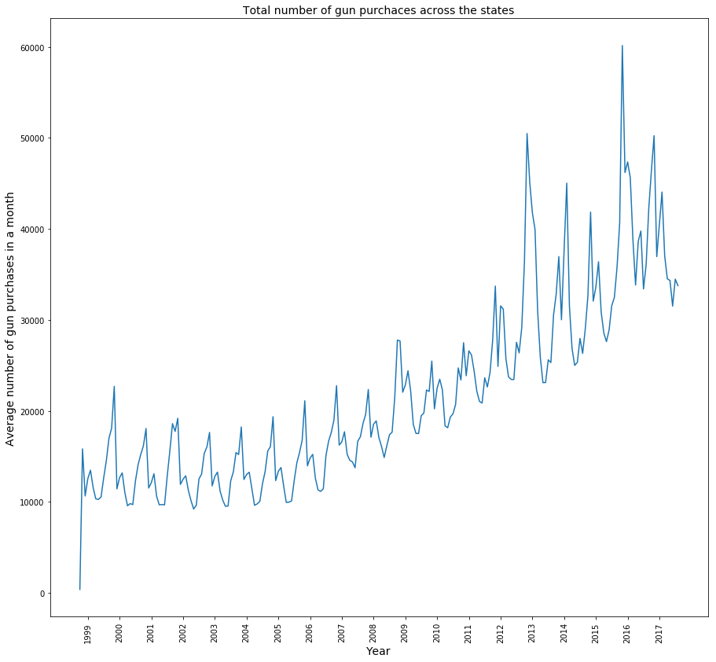

```python
"""Plotting the average number of gun purchases over the years"""

plt.figure(figsize=(15,14))
df1.groupby(['month'])['totals'].mean().plot()

"""Getting the xtick positions"""
x=[]
for i in np.arange(3,228,12):
  x.append(i)

"""Getting the xtick labels that correspond to the year of gun purchase"""
label_x=[]
for i in np.arange(1999,2018,1):
  label_x.append(i)


plt.xticks(x, label_x, rotation='vertical')
plt.title('Total number of gun purchaces across the states',fontsize=14)
plt.ylabel('Average number of gun purchases in a month',fontsize=14)
plt.xlabel('Year',fontsize=14);
```

**2. Despite having a variety of gun, we will here restrict ourselves with handguns and long guns. At first, we will have a look at the number of handgun purchases by state.**

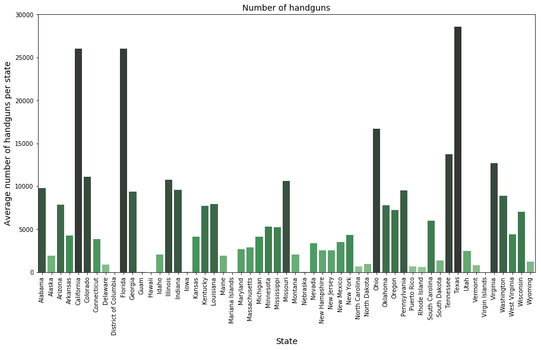

```python
"""Plotting the average number of handgun purchases for different states"""
plt.figure(figsize=(15,8))
res=df1.groupby(['state'])['handgun'].mean()
pal = sns.color_palette("Greens_d", len(res))
rank = res.argsort().argsort()   # http://stackoverflow.com/a/6266510/1628638
final_plot = sns.barplot(x=res.index, y=res, palette=np.array(pal[::-1])[rank])
for item in final_plot.get_xticklabels():
    item.set_rotation(90);

plt.title('Number of handguns',fontsize=14)
plt.ylabel('Average number of handguns per state',fontsize=14)
plt.xlabel('State',fontsize=14);
```

**The number of hand guns purchases on aan average are the largest in California, Florida and Texas.**

**Secondly, we will have a look at the number of long gun purchases by state.**

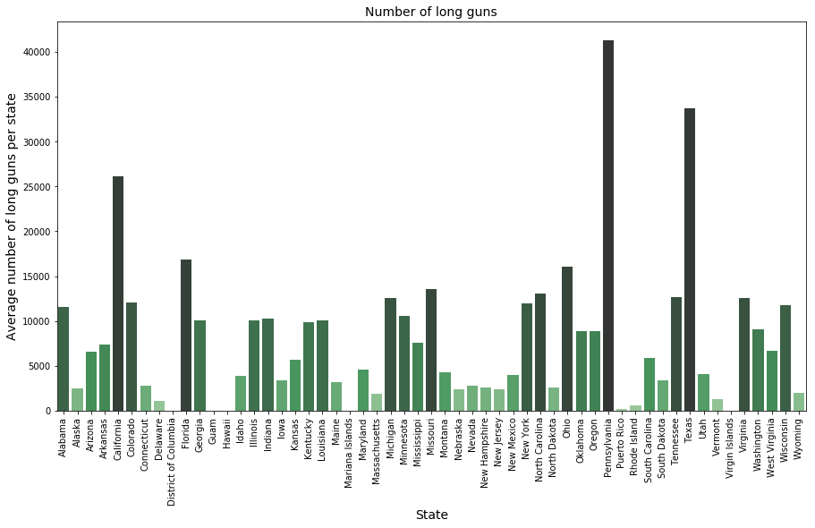

```python
"""Plotting the average number of long gun purchases for different states"""
plt.figure(figsize=(15,8))
res=df1.groupby(['state'])['long_gun'].mean()
pal = sns.color_palette("Greens_d", len(res))
rank = res.argsort().argsort()   # http://stackoverflow.com/a/6266510/1628638
final_plot = sns.barplot(x=res.index, y=res, palette=np.array(pal[::-1])[rank])
for item in final_plot.get_xticklabels():
    item.set_rotation(90);

plt.title('Number of long guns',fontsize=14)
plt.ylabel('Average number of long guns per state',fontsize=14)
plt.xlabel('State',fontsize=14);
```

**Here, we will have a look at the number of total number of gun purchases by state.**

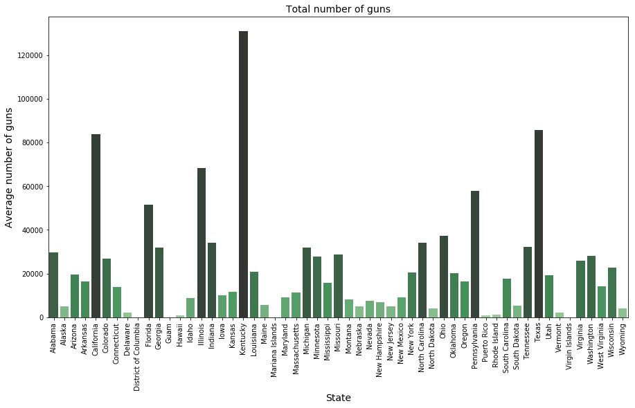

```python
"""Plotting the average number of total gun purchases/rentals for different states"""
plt.figure(figsize=(15,8))


res=df1.groupby(['state'])['totals'].mean()
pal = sns.color_palette("Greens_d", len(res))
rank = res.argsort().argsort()   # http://stackoverflow.com/a/6266510/1628638
final_plot = sns.barplot(x=res.index, y=res, palette=np.array(pal[::-1])[rank])
for item in final_plot.get_xticklabels():
    item.set_rotation(90);

plt.title('Total number of guns',fontsize=14)
plt.ylabel('Average number of guns',fontsize=14)
plt.xlabel('State',fontsize=14);
```

**Another thing to notice is that, there is no one-to-one correlation between the largest hand gun/long gun purchasing state and the overall large purchaser since we have neglected the other types of guns in the sample considered.**

**After having identified the largest buyer, Kentucky, if not the largest in long gun/handgun, we will look at its subtler aspects in terms of the types of handgun/long gun that has been purchased by it.** **Since there are several null values before 2015 for the other columns, we will use the trimmed dataset 'after_2015' to look at the split for Kentucky.**

```python
"""Identifying the split up of different parameters for the state with largest gun purchaser/rental"""
after_2015.loc[after_2015['totals'].idxmax()]
```

```
month                         2017-09
state                        Kentucky
permit                         378384
handgun                          8112
long_gun                         7543
prepawn_handgun                    16
prepawn_long_gun                   15
redemption_handgun               1915
redemption_long_gun              1875
returned_handgun                    1
returned_long_gun                   1
private_sale_handgun               21
private_sale_long_gun              19
return_to_seller_handgun            2
return_to_seller_long_gun           1
totals                         398706
Name: 18, dtype: object
```

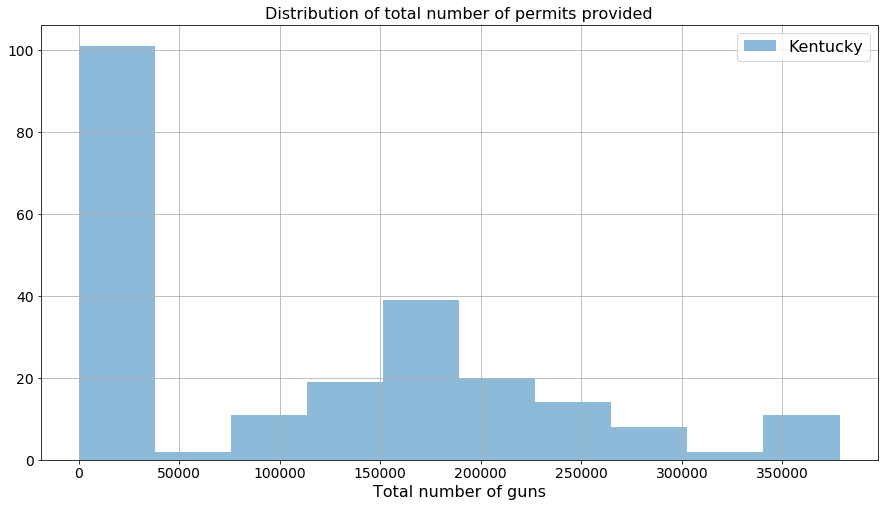

```python
"""Identifying the distribution of the permits of the state with largest gun purchaser/rentals"""

plt.figure(figsize=(15,8))


df1.permit[df1['state'] == 'Kentucky'].hist(alpha=0.5,label='Kentucky')

plt.title('Distribution of total number of permits provided',fontsize=16)
plt.xlabel('Total number of guns',fontsize=16)
plt.xticks(fontsize=14)
plt.yticks(fontsize=14)
plt.legend(fontsize =16);
```

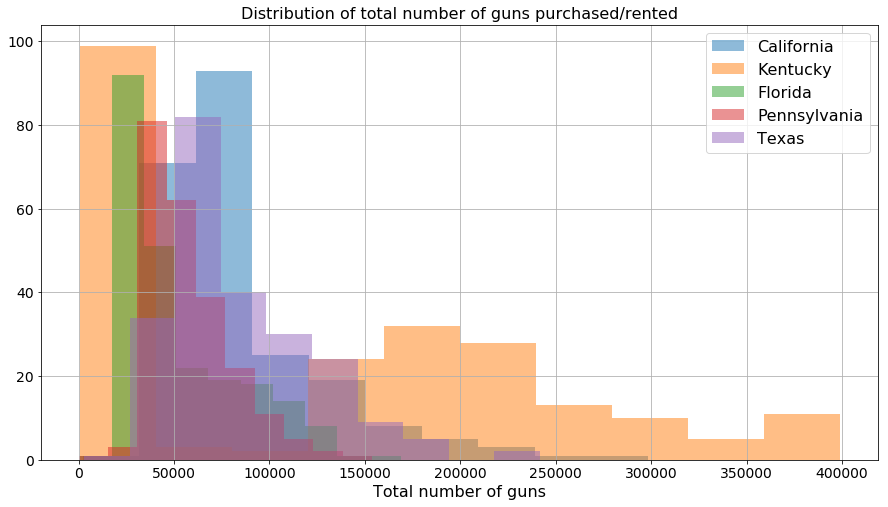

```python
"""Identifying the distribution of the state with largest gun purchaser/rentals"""

plt.figure(figsize=(15,8))

df1.totals[df1['state'] == 'California'].hist(alpha=0.5,label='California')
df1.totals[df1['state'] == 'Kentucky'].hist(alpha=0.5,label='Kentucky')
df1.totals[df1['state'] == 'Florida'].hist(alpha=0.5,label='Florida')
df1.totals[df1['state'] == 'Pennsylvania'].hist(alpha=0.5,label='Pennsylvania')
df1.totals[df1['state'] == 'Texas'].hist(alpha=0.5,label='Texas')


plt.title('Distribution of total number of guns purchased/rented',fontsize=16)
plt.xlabel('Total number of guns',fontsize=16)
plt.xticks(fontsize=14)
plt.yticks(fontsize=14)
plt.legend(fontsize =16);
```

## Conclusions

**Limitations**  
**1. Here, we consider datat only from the handguns, long guns and the total purchases/rentals while there are several other variables that are not considered, and needs further analysis.**  
**2. For many of the columsn the data is not present, and hence for a selected plot we do not consider an overall view, for example to understand the composition of gun purchases/rentals with respect to Kentucky. Hence, one needs to have an entire sample set below 2015 to be able to provide accurate predictions with respect to other parameters other than hand guns/long guns/totals.**  
**3. Further, it is also possible to correlate the population of each state along with the purchases, which would be an added value to the analysis which again is beyond the scope of the project, and not considered here.**